# C02 — Surowy eksport: braki, duplikaty i jawne czyszczenie

Zarządzanie informacją — ćwiczenie i zadanie Z02 — 2026/27

2026/27

# Początek pracy na ćwiczeniu C02

Otwórz swój projekt kursu w Posit Cloud albo RStudio na własnym komputerze; pakiet kursu `badaniaZI` jest w nim zainstalowany. Dwa polecenia z następnego bloku wpisujesz w konsoli RStudio, czyli w dolnym panelu ze znakiem `>`; w miejsce `TWOJE_ID` wpisz swoje ID, a w miejsce `Imię Nazwisko` — swoje imię i nazwisko. Dokument PDF zawiera dwa polecenia jako tekst instrukcji.

```r
library(badaniaZI)
rozpocznij_zajecia("C02", id_studenta = "TWOJE_ID", student = "Imię Nazwisko")
```

Sprawdź w komunikacie ID oraz imię i nazwisko. Przy pierwszym starcie funkcja tworzy folder `moje-badania` i zapisuje w nim oba dane; pliki pracy zachowują je także po zamknięciu projektu, a imię i nazwisko trafiają do nazwy oddawanego pliku.

Funkcja `rozpocznij_zajecia()` otwiera własny plik `zadanie.Rmd`, zapamiętuje katalog pracy i kopiuje do folderu `moje-badania/materialy` wersję HTML i PDF ćwiczenia oraz rubrykę zadania. Pracuj w otwartym pliku `zadanie.Rmd` do końca zajęć. Najpierw uruchom blok `przygotowanie`, a potem kolejne części LEARN i CHALLENGE. Przy problemie poproś prowadzącego o pomoc; plik pracy i własne ID pozostają bez zmian.

Plik ćwiczenia łączy tekst z blokami kodu R (chunkami), które uruchamiasz zieloną strzałką w prawym górnym rogu bloku albo skrótem Ctrl+Shift+Enter. Pierwszy chunk, `przygotowanie`, wczytuje gotowy skrypt `analiza.R`. Skrypt tworzy trzy zbiory: mały eksport demonstracyjny badania katalogu (nagłówek i siedem wierszy opisujących osoby u01–u06), eksport badania cyfrowego archiwum (nagłówek i siedem wierszy opisujących osoby a01–a06) oraz zbiór S02 po przygotowaniu (148 osób). Skrypt zawiera też funkcje wyświetlające tabele i wykresy i działa bez zmian.

Zbiór S02 przygotowuje funkcja pakietu `przygotuj_ankiete()`. Funkcja stosuje trzy reguły: usuwa identyczne duplikaty rekordów, zamienia kod 99 w pozycjach ankiety na `NA` i oznacza jako `NA` czasy spoza zakresu 0–120 minut. Plik surowy pozostaje bez zmian, a wszystkie porównania działają na kopiach w pamięci R. Każdy chunk zapisuje wynik funkcji w obiekcie, a `print()` wyświetla obiekt w dokumencie, tak jak na ćwiczeniu C01.

# Dlaczego dwie osoby otrzymały różne średnie

Zespół biblioteki przekazał tę samą ankietę dwóm analitykom. Pierwsza osoba potraktowała 99 jako odpowiedź na skali oceny, druga rozpoznała w 99 kod braku. Pierwsza usunęła każdy wiersz z pustym polem, druga zachowała wiersze do analiz, w których miały potrzebne informacje. Z jednego pliku powstały różne liczebności i różne podsumowania.

Część różnic wynika z różnych pytań: analiza czasu wymaga ważnego czasu, a analiza indeksu — pięciu ważnych pozycji ankiety. Różnica staje się problemem, gdy decyzja pozostaje ukryta albo pozbawiona uzasadnienia. Ćwiczenie C02 uczy czytać czyszczenie danych jako serię decyzji o znaczeniu danych.

Ćwiczenie C01 wprowadziło rekord, zmienną, brak i mianownik. Ćwiczenie C02 stosuje te pojęcia do surowego eksportu. Reguły czyszczenia wynikają ze słownika, projektu i procesu pomiaru, a ustala się je przed obliczeniem wyników. Wynik obliczeń pozostaje poza uzasadnieniem reguły.

Przeznacz około 5 minut na odtworzenie pracy, 30 minut na pięć bloków LEARN, 50 minut na pięć zadań CHALLENGE i 5 minut na zapis oraz oddanie. LEARN to część z gotowymi przykładami i wzorcową interpretacją; CHALLENGE to pięć odpowiedzi, które piszesz samodzielnie pod wynikami. Gdy odczyt wyniku sprawia trudność, pytasz prowadzącego.

Dane projektu indywidualnego poznasz na ćwiczeniu C09 (Warsztat projektu). Na C02 pracujesz na gotowym eksporcie, słowniku i procedurze przygotowania, a Twoim zadaniem jest opis skutków procedury. Rozwinięcia po CHALLENGE służą powtórce i pozostają poza oceną.

Bloki LEARN kończą się **wzorcem zapisu** — przykładowym zdaniem według standardu APA (*Publication Manual of the American Psychological Association*, 7. wydanie, 2020): symbol statystyczny kursywą, jednostka przy liczbie, przecinek jako separator dziesiętny. Na ćwiczeniu C02 wzorce dotyczą części metodycznej raportu: wczytania danych, duplikatów, braków i liczebności. Zadania CHALLENGE stosują wzorce do eksportu cyfrowego archiwum.

# Surowy plik i dokumenty, które go objaśniają

W LEARN pracujemy na małym eksporcie badania katalogu: siedem rekordów opisuje sześć osób. CHALLENGE dotyczy odrębnego badania cyfrowego archiwum. Pełny zbiór S02 wraca w rozwinięciu po CHALLENGE. Wszystkie dane są syntetyczne i opisujemy je jako dane dydaktyczne; znaczenie przygotowanych sytuacji odczytujemy ze słownika.

Surowy plik jest punktem odniesienia. Pozostaje bez zmian, a reguły zapisuje skrypt. Zachowany plik i skrypt pozwalają odtworzyć wynik, porównać dwie uzasadnione decyzje i sprawdzić N podane w raporcie. Ręczna zmiana komórek w arkuszu bez dziennika usuwa możliwość kontroli wyniku.

| Dokument lub obiekt | Co pozwala ustalić? | Co wymaga drugiego źródła? |
| --- | --- | --- |
| Surowy CSV | Wartości przekazane do analizy | Przyczyny wartości: protokół obserwacji |
| Słownik | Jednostki, kody, zakresy i znaczenie pól | Prawdziwość wartości: kontrola zapisu |
| Protokół obserwacji | Początek, koniec i warunki zadania | Sposób eksportu: skrypt eksportu |
| Skrypt przygotowania | Zastosowane przekształcenia | Sens badawczy reguły: projekt badania |
| Dziennik zmian | Liczbę rekordów lub komórek objętych regułą | Mechanizm powstawania braków: projekt i protokół |
| Tabela analityczna | Dane, z których obliczono wynik | Stan przed przekształceniem: surowy plik |

Kontrola składniowa sprawdza zapis, a kontrola merytoryczna — znaczenie. Program sprawdza, czy czas jest liczbą nieujemną. Znaczenie wartości 8 — minuty aktywnego szukania, czas całej sesji albo czas do rezygnacji — podaje projekt badania.

# LEARN 1: plik CSV jest tekstem z umową

CSV przechowuje tabelę jako tekst. Umowa pliku obejmuje separator kolumn, znak dziesiętny, zapis braków i kodowanie znaków. Każdy program odczytuje plik `.csv` według własnych ustawień, więc polecenie importu podaje separator, znak dziesiętny i kodowanie jawnie.

Eksport `eksport_demo` ma nagłówek i siedem wierszy. Kolumny rozdziela średnik, liczby dziesiętne zapisano z przecinkiem, a puste pole oznacza brak. Odczytaj najpierw nagłówek, a następnie pojedynczy rekord; dwa sąsiednie średniki oznaczają puste pole.

```r
eksport <- tekst_eksportu(eksport_demo)
print(eksport)
```

```
id;grupa;czas_min;ocena;powodzenie
u01;nowi;6,5;4;1
u02;nowi;8,0;99;0
u02;nowi;8,0;99;0
u03;doświadczeni;4,5;5;1
u04;doświadczeni;;3;
u05;nowi;-2,0;2;0
u06;doświadczeni;35,0;4;1
```

Wiersz u02 występuje dwa razy z identycznymi polami. Pole `ocena` u02 zawiera 99, czyli kod braku według słownika demonstracji. Wiersz u04 ma puste pola czasu i powodzenia. Wiersz u05 ma czas −2 minuty, a u06 — długi czas 35 minut, mieszczący się w zakresie 0–120 minut przyjętym dla danych kursu.

Duplikat, kod 99, ujemny czas i długi czas wymagają czterech różnych reakcji. Identyczny duplikat usuwa się jako nadmiarowy rekord. Kod braku zmienia znaczenie komórki. Ujemny czas wymaga sprawdzenia w źródle albo oznaczenia jako brak. Długi czas w zakresie pozostaje obserwacją do chwili, gdy protokół dostarczy dowodu błędu.

Funkcja `import_demo()` ma podaną właściwą umowę: średnik jako separator i przecinek jako znak dziesiętny. Tabela „Poprawny import” ma pięć kolumn i siedem rekordów, a czasy są liczbami, choć tekst źródłowy zawiera przecinki.

```r
dane_importu <- pokaz_tabele(surowe_demo, "Poprawny import")
print(dane_importu)
```

**Poprawny import**

| id | grupa | czas_min | ocena | powodzenie |
| --- | --- | --- | --- | --- |
| u01 | nowi | 6,5 | 4 | 1 |
| u02 | nowi | 8,0 | 99 | 0 |
| u02 | nowi | 8,0 | 99 | 0 |
| u03 | doświadczeni | 4,5 | 5 | 1 |
| u04 | doświadczeni | NA | 3 | NA |
| u05 | nowi | -2,0 | 2 | 0 |
| u06 | doświadczeni | 35,0 | 4 | 1 |

Siedem rekordów to liczba wierszy tabeli. Liczbę osób ustala kontrola identyfikatorów i duplikatów: w demonstracji siedem rekordów opisuje sześć osób.

## Separator kolumn a znak dziesiętny

Właściwy separator kolumn z niewłaściwym znakiem dziesiętnym daje tabelę o poprawnym wyglądzie, w której czas pozostaje tekstem. Błąd znaku dziesiętnego trudniej rozpoznać niż sklejenie wszystkich pól w jedną kolumnę. Kontrola importu obejmuje więc klasę każdej kolumny.

Blok `import-bledny-typ` odczytuje eksport z kropką jako oczekiwanym znakiem dziesiętnym. Błędny import powstaje jako osobny obiekt. Tabela „Typ zapisu i liczba braków” podaje klasę `character` kolumny `czas_min`: program odczytał czasy jako tekst.

```r
bledny_import <- kontrola_typow(import_demo(dziesietny = "."))
print(bledny_import)
```

**Typ zapisu i liczba braków**

| kolumna | klasa_R | braki |
| --- | --- | --- |
| id | character | 0 |
| grupa | character | 0 |
| czas_min | character | 1 |
| ocena | integer | 0 |
| powodzenie | integer | 1 |

Błędny separator kolumn daje jedną długą kolumnę albo różną liczbę pól w wierszach. Błędne kodowanie znaków uszkadza nazwy kategorii, np. „doświadczeni”. Błędny znak dziesiętny zmienia liczby w tekst. Każdy z trzech problemów rozpoznaje osobna kontrola.

W poprawnym imporcie tabela „Typ zapisu i liczba braków” podaje: `id` i `grupa` mają klasę `character` i 0 braków; `czas_min` ma klasę `numeric` i 1 brak (u04); `ocena` ma klasę `integer` i 0 braków; `powodzenie` ma klasę `integer` i 1 brak (u04). Program traktuje kod 99 jako liczbę, więc kolumna `ocena` ma 0 braków.

```r
poprawny_import <- kontrola_typow(surowe_demo)
print(poprawny_import)
```

**Typ zapisu i liczba braków**

| kolumna | klasa_R | braki |
| --- | --- | --- |
| id | character | 0 |
| grupa | character | 0 |
| czas_min | numeric | 1 |
| ocena | integer | 0 |
| powodzenie | integer | 1 |

## Klasa R i skala pomiaru

Klasa R opisuje zapis techniczny, a skala pomiaru — znaczenie wartości. Program zapisuje ocenę jako liczbę całkowitą, a słownik określa ją jako pozycję porządkową z odpowiedziami 1–5. Kod 99 ma klasę `integer` i leży poza skalą 1–5. Uznanie wartości za pomiar wymaga zgodności z klasą i ze słownikiem.

Identyfikator „0012” zachowuje zera wiodące, gdy są częścią klucza; zamiana na liczbę 12 uniemożliwia połączenie z inną tabelą. Numer karty bibliotecznej jest etykietą nominalną zapisaną cyframi.

Klasa `factor` przechowuje kategorie jako poziomy o kolejnych numerach. Numer poziomu wynika z kolejności etykiet, a wartość skali podaje słownik; mechaniczna konwersja kategorii na liczby tworzy więc inną zmienną. Gotowy skrypt kursu wykonuje konwersje, a Twoim zadaniem jest odczyt sensu wyniku.

| Kolumna | Pytanie o zapis | Pytanie o pomiar |
| --- | --- | --- |
| ID | Czy zachowano tekst i zera wiodące? | Czy ID jednoznacznie wskazuje jednostkę? |
| Grupa | Czy zapis etykiet jest spójny? | Na jakiej podstawie przypisano doświadczenie? |
| Czas | Czy R rozpoznaje liczby? | Od jakiego do jakiego zdarzenia mierzono czas? |
| Ocena | Czy 99 oznaczono jako brak? | Co znaczy każda kategoria odpowiedzi? |
| Powodzenie | Czy kolumna zawiera wyłącznie 0, 1 i NA? | Kto oceniał poprawność i według jakiego kryterium? |

Etykiety „nowi” i „nowi ” (ze spacją na końcu) R traktuje jako dwie kategorie, bo końcowa spacja jest częścią tekstu. Usunięcie nadmiarowych spacji jest uzasadnione, gdy dokumentacja potwierdza, że obie etykiety oznaczają tę samą kategorię. Łączenie etykiet obejmuje wyłącznie zapisy tej samej kategorii.

**Wzorzec zapisu importu (APA).**

> Dane wczytano z pliku CSV (separator pól: średnik, znak dziesiętny: przecinek). Eksport zawierał 7 rekordów i 5 zmiennych; czas zadania odczytano jako zmienną liczbową w minutach, a ocenę — jako liczbę całkowitą na skali 1–5 z kodem braku 99.

# LEARN 2: duplikat i konflikt identyfikatora

Identyczny duplikat powtarza cały rekord. W demonstracji u02 ma dwa wiersze z tymi samymi danymi. Eksport zawiera jeden pomiar na osobę, więc dodatkowa kopia powtarza tę samą obserwację i podwaja jej wagę w średniej i odsetku.

Tabela „Po usunięciu identycznej kopii” ma sześć wierszy i sześć różnych identyfikatorów. Kod 99 u02 i ujemny czas u05 pozostają w tabeli do zastosowania kolejnych reguł: jedna reguła rozwiązuje jeden rodzaj problemu.

```r
unikalne <- pokaz_tabele(unikalne_demo, "Po usunięciu identycznej kopii")
print(unikalne)
```

**Po usunięciu identycznej kopii**

| id | grupa | czas_min | ocena | powodzenie |
| --- | --- | --- | --- | --- |
| u01 | nowi | 6,5 | 4 | 1 |
| u02 | nowi | 8,0 | 99 | 0 |
| u03 | doświadczeni | 4,5 | 5 | 1 |
| u04 | doświadczeni | NA | 3 | NA |
| u05 | nowi | -2,0 | 2 | 0 |
| u06 | doświadczeni | 35,0 | 4 | 1 |

Wartości pomiarów pozostały takie same. Dziennik zapisuje liczbę usuniętych rekordów: 1.

Konflikt identyfikatora oznacza ten sam identyfikator z różnymi wartościami. Tabela „Ten sam identyfikator, różne wyniki” jest osobnym przypadkiem diagnostycznym: dwa wiersze u02 z czasem 8 i 18 minut oraz powodzeniem 0 i 1.

```r
konflikt <- pokaz_tabele(konflikt_demo, "Ten sam identyfikator, różne wyniki")
print(konflikt)
```

**Ten sam identyfikator, różne wyniki**

| id | czas_min | powodzenie |
| --- | --- | --- |
| u02 | 8 | 0 |
| u02 | 18 | 1 |

Dwie wersje mogą pochodzić z poprawionego pomiaru, dwóch zadań tej samej osoby albo błędu przypisania ID. Wybór wersji wymaga źródła: protokołu, numeru zadania lub informacji o wersji. Funkcja `przygotuj_ankiete()` zatrzymuje analizę przy konflikcie i wskazuje identyfikator do wyjaśnienia.

Gdy osoba wykonała dwa zadania, oba rekordy są poprawne. Wiersz oznacza wtedy parę osoba–zadanie, a analiza wymaga agregacji do jednej wartości na osobę albo modelu pomiarów zależnych. Usunięcie powtórzonego ID usunęłoby wtedy część badania.

**Wzorzec zapisu duplikatów (APA).**

> Eksport zawierał 7 rekordów; identyczną kopię rekordu u02 usunięto, więc analizy objęły 6 osób. Kontrola identyfikatorów wykazała 0 konfliktów, czyli przypadków tego samego identyfikatora z różnymi wartościami.

# LEARN 3: kod braku 99

Słownik demonstracji określa odpowiedzi od 1 do 5 oraz kod 99 oznaczający brak. Zamiana 99 na `NA` rozpoznaje brak odpowiedzi. Imputacja, czyli uzupełnienie brakującego wyniku wartością oszacowaną, jest osobną metodą.

Tabela „Wpływ kodu 99 na rachunek średniej” porównuje średnią surowych liczb ze średnią ważnych odpowiedzi. Pięć ważnych ocen po usunięciu duplikatu to 4, 5, 3, 2 i 4, o sumie 18. Oznaczmy przez $W$ zbiór osób z ważną odpowiedzią, przez $n$ liczbę ważnych odpowiedzi, a przez $m$ liczbę kodów 99:

$$\bar{x}_{99}=\frac{\sum_{i\in W}x_i+99\,m}{n+m}=\frac{18+99}{5+1}=19{,}5,
\qquad
\bar{x}=\frac{\sum_{i\in W}x_i}{n}=\frac{18}{5}=3{,}6 .$$

Średnia $\bar{x}_{99}$ wlicza kod jako odpowiedź i leży poza skalą 1–5, a średnia $\bar{x}$ opisuje pięć ważnych odpowiedzi. Wynik spoza zakresu skali sygnalizuje błąd w przygotowaniu danych.

```r
kody <- pokaz_tabele(skutek_kodu, "Wpływ kodu 99 na rachunek średniej")
print(kody)
```

**Wpływ kodu 99 na rachunek średniej**

| wariant | N | srednia |
| --- | --- | --- |
| Kod 99 błędnie traktowany jak odpowiedź | 6 | 19,5 |
| Wyłącznie ważne odpowiedzi 1–5 | 5 | 3,6 |

Kod 99 wpływa także na rozrzut wyników, histogram, korelację i indeks. Błąd na etapie przygotowania przenosi się do wszystkich dalszych analiz, dlatego kontrola wejścia poprzedza każdą analizę.

Kod 99 oznacza brak w pozycjach ankiety; w kolumnie czasu 99 minut jest pomiarem mieszczącym się w zakresie 0–120 minut. Regułę stosuje się do wskazanych pól i wskazanego znaczenia. Zamiana każdej wartości 99 w całym pliku byłaby inną, nieuzasadnioną operacją.

| Zapis odpowiedzi | Znaczenie w projekcie | Postępowanie |
| --- | --- | --- |
| 0 w powodzeniu | Zadanie zakończone niepowodzeniem | Zachowaj jako wynik |
| 0 w czasie | Pomiar na dolnej granicy zakresu | Odczytaj w kontekście zadania |
| 99 w pozycji oceny | Kod braku według słownika | Zamień na NA w tej pozycji |
| Puste pole | Brak zapisu | Zachowaj brak i wyjaśnij jego pochodzenie |
| „Nie dotyczy” | Pytanie bez zastosowania dla osoby | Zachowaj odrębne znaczenie w protokole |
| „Nie wiem” | Odpowiedź o stanie wiedzy | Postępuj według definicji pytania |

Odpowiedź „Nie wiem” opisuje stan wiedzy i tworzy osobną kategorię, ważną np. w pytaniu o znajomość procedury. Analiza skali od zdecydowanej niezgody do zgody obejmuje odpowiedzi 1–5, a sposób analizy kategorii „Nie wiem” wynika z celu pytania.

## Wartość niemożliwa i wartość nietypowa

Czas −2 minuty leży poza zakresem pomiaru czasu wykonania zadania. Powstaje np. przez zamianę znaczników początku i końca albo literówkę. Poprawka wymaga zapisu źródłowego i wpisu w dzienniku; bez zapisu źródłowego wartość oznaczamy jako brak.

W danych dydaktycznych obowiązuje jawna reguła: czasy poza 0–120 minut oznaczamy jako brak. Zakres 0–120 minut jest regułą zbioru kursowego; w rzeczywistym projekcie zakres wynika z protokołu, limitu czasu i sposobu rejestracji.

Tabela „Zmiany komórek przy zachowaniu osób” zestawia komórki przed regułami i po nich. Zmieniły się dwie komórki: ocena u02 z 99 na `NA` i czas u05 z −2 na `NA`. Reguły zmieniają komórki, a rekordy zostają: u02 zachowuje czas 8 minut i wynik 0, a u05 — ocenę 2 i wynik 0.

```r
zmiany <- pokaz_tabele(roznice_komorek, "Zmiany komórek przy zachowaniu osób")
print(zmiany)
```

**Zmiany komórek przy zachowaniu osób**

| id | czas_przed | czas_po | ocena_przed | ocena_po |
| --- | --- | --- | --- | --- |
| u01 | 6,5 | 6,5 | 4 | 4 |
| u02 | 8,0 | 8,0 | 99 | NA |
| u03 | 4,5 | 4,5 | 5 | 5 |
| u04 | NA | NA | 3 | 3 |
| u05 | -2,0 | NA | 2 | 2 |
| u06 | 35,0 | 35,0 | 4 | 4 |

Czas 35 minut pozostaje w tabeli. Jest znacznie dłuższy od pozostałych i mieści się w przyjętym zakresie. Nietypowość jest powodem do sprawdzenia kontekstu. Długie próby bywają dla instytucji najważniejszą informacją o barierze usługi.

Wykres „Długi czas pozostaje obserwacją” ma na osi poziomej osoby, a na osi pionowej czas w minutach. Zawiera cztery ważne czasy po przygotowaniu: u01 6,5; u02 8,0; u03 4,5; u06 35,0 minuty. Osoba u04 ma puste pole, a czas u05 oznaczono jako brak. Decyzja o błędzie wymaga dowodu z protokołu.

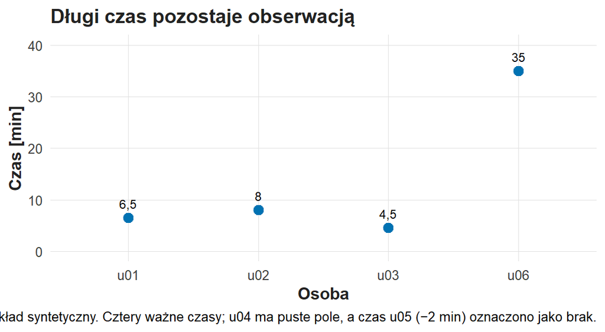

Długi czas pozostaje obserwacją. Oś pozioma: osoby u01, u02, u03 i u06; oś pionowa: czas w minutach od 0 do 40. Punkty z podpisami: 6,5; 8,0; 4,5 i 35,0 minuty; punkt u06 leży wyraźnie wyżej od trzech pozostałych.

```r
czasy_osob <- pokaz_wykres(wykres_decyzji)
print(czasy_osob)
```

## Wykres pudełkowy i granica wąsa

Wykres pudełkowy streszcza rozkład pięcioma liczbami. Kwartyle dzielą uporządkowane wartości na cztery części: pierwszy kwartyl $Q_1$ oddziela najniższą ćwiartkę, mediana — połowę, trzeci kwartyl $Q_3$ — najwyższą ćwiartkę. Pudełko obejmuje wartości od $Q_1$ do $Q_3$, a kreska w pudełku oznacza medianę. Rozstęp międzykwartylowy $IQR=Q_3-Q_1$ jest długością pudełka. Wąsy sięgają do najbardziej skrajnych obserwacji leżących w odległości co najwyżej $1{,}5\,IQR$ od pudełka.

Dla czterech ważnych czasów 4,5; 6,5; 8 i 35 minut R oblicza kwartyle przez interpolację między sąsiednimi wartościami uporządkowanymi: $Q_1=6{,}0$, mediana $7{,}25$, $Q_3=14{,}75$ minuty. Górna granica wąsa wynosi

$$Q_3+1{,}5\,IQR=14{,}75+1{,}5\cdot(14{,}75-6{,}0)=14{,}75+13{,}125\approx 27{,}9 \text{ minuty}.$$

Przedział od 14,75 do 27,9 minuty jest pusty, więc górny wąs ma zerową długość i kończy się na prawej krawędzi pudełka. Czas 35 minut leży poza granicą wąsa i pozostaje prawidłową obserwacją: granica wąsa jest konwencją graficzną, a rozpoznanie błędu wymaga protokołu.

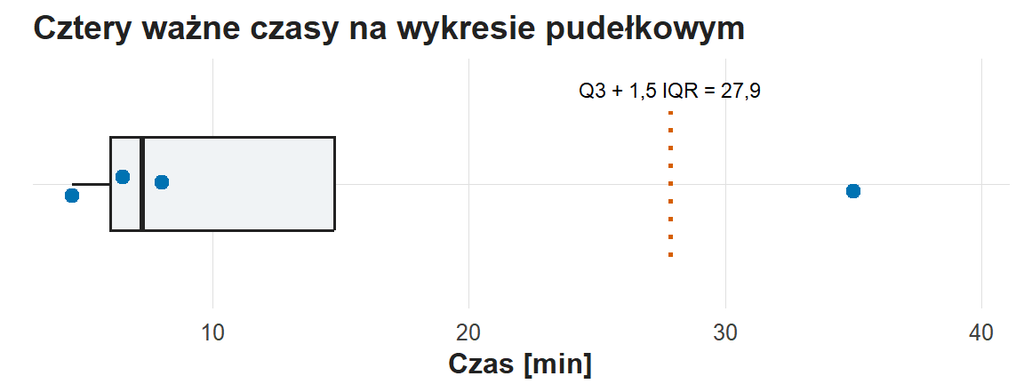

Cztery ważne czasy na wykresie pudełkowym. Oś pozioma: czas w minutach. Pudełko obejmuje czasy od 6,0 do 14,75 minuty, kreska mediany leży przy 7,25 minuty; kropkowana linia oznacza granicę Q3 + 1,5 IQR = 27,9 minuty, a punkt 35 minut leży na prawo od granicy.

```r
pudelko <- pokaz_wykres(wykres_pudelka)
print(pudelko)
```

Automatyczne usuwanie punktów spoza wąsów zmienia badane zjawisko: opis obejmuje wtedy wyłącznie osoby, którym poszło podobnie do większości. Czas wyszukiwania ma zwykle rozkład z długim prawym ogonem, więc punkty poza wąsem są w nim oczekiwane; ćwiczenie C03 (Portret próby) opisuje taki rozkład miarami.

## Skutek usunięcia prawidłowego długiego czasu

Analiza wrażliwości porównuje wyniki przy nazwanej alternatywie ustalonej przed porównaniem liczb. Gdy alternatywa zmienia analizowaną populację albo definicję wyniku, opis podaje tę zmianę przed liczbami.

Tabela „Konsekwencja wykluczenia prawidłowego pomiaru” opisuje konsekwencję usunięcia czasu 35 minut: średnia spada z 13,5 do 6,33 minuty, mediana z 7,25 do 6,5 minuty, a N z 4 do 3.

```r
warianty <- porownanie_wrazliwosci(wrazliwosc_czasu)
print(warianty)
```

**Konsekwencja wykluczenia prawidłowego pomiaru**

| Wariant | N | Średnia [min] | Mediana [min] |
| --- | --- | --- | --- |
| Wszystkie ważne pomiary | 4 | 13,500 | 7,25 |
| Po usunięciu poprawnego czasu 35 min | 3 | 6,333 | 6,50 |

Średnia zmienia się silnie, bo czas 35 minut stanowi 35 z 54 minut łącznego nakładu. Mediana zależy od kolejności wartości i zmienia się o 0,75 minuty. Ćwiczenie C03 rozwija różnicę między średnią a medianą. Na C02 najważniejsze jest pytanie o opisywany zbiór: wszystkie osoby z ważnym czasem albo osoby po wykluczeniu najdłuższej próby.

Czas 35 minut może obejmować udokumentowaną przerwę techniczną. Analiza aktywnego czasu wymaga wtedy zmierzonej długości przerwy; przypuszczenie o przerwie pozostaje przypuszczeniem.

W rzeczywistym projekcie warto zaplanować rejestrację przerw, pomocy bibliotekarza i przerwania zadania. Takie pola oddzielają trudność wyszukiwania od technicznego zakłócenia. Brak pól o przerwach jest ograniczeniem pomiaru, zapisywanym w raporcie.

**Wzorzec zapisu braków i analizy wrażliwości (APA).**

> Kod 99 w pozycji oceny (1 odpowiedź) oznaczono jako brak danych, a czas −2 min jako wartość spoza zakresu 0–120 min; średnia ocena pięciu ważnych odpowiedzi wyniosła *M* = 3,60 (skala 1–5). Cztery ważne czasy dały *M* = 13,50 min (*Mdn* = 7,25 min); po wyłączeniu prawidłowego pomiaru 35 min średnia wyniosłaby *M* = 6,33 min (*n* = 3), więc pomiar pozostaje w analizie.

# LEARN 4: rachunek liczebności

Dziennik pozwala odtworzyć zmiany wierszy i zmiany poszczególnych zmiennych. Liczba osób i liczba ważnych wartości to dwie różne wielkości: zamiana 99 na brak zmniejsza N oceny o 1, a liczba rekordów pozostaje równa 6.

$$N_{\mathrm{po}}=N_{\mathrm{surowe}}-N_{\mathrm{duplikatów}},
\qquad
n_X=N_{\mathrm{po}}-m_X .$$

Pierwszy wzór liczy wiersze: $7-1=6$. Drugi liczy ważne wartości zmiennej $X$: $m_X$ to liczba braków $X$ po zastosowaniu reguł, a $n_X$ liczba ważnych wartości. Dla czasu $n_{\mathrm{czas}}=6-2=4$ (braki u04 i u05), dla oceny $n_{\mathrm{ocena}}=6-1=5$ (brak u02), dla powodzenia $n_{\mathrm{wynik}}=6-1=5$ (brak u04). Liczba osób i liczba zmienionych komórek to dwie osobne wielkości dziennika.

| Symbol | Odczyt | Znaczenie w demonstracji |
| --- | --- | --- |
| $N_{\mathrm{surowe}}$ | liczba surowych rekordów | Siedem wierszy eksportu |
| $N_{\mathrm{duplikatów}}$ | liczba nadmiarowych kopii | Jeden identyczny wiersz |
| $N_{\mathrm{po}}$ | liczba rekordów po deduplikacji | Sześć osób |
| $m_X$ | liczba braków zmiennej $X$ | Dla czasu 2, dla oceny 1 |
| $n_X$ | liczba ważnych wartości $X$ | Mianownik opisu zmiennej |
| $n_{XY}$ | liczba kompletnych par $X$ i $Y$ | Podstawa analizy związku |

Tabela „Rekordy oraz niebrakujące wartości na kolejnych etapach” podaje dla trzech etapów liczby rekordów, czasów, ocen i wyników. Etap „surowe”: 7 rekordów, 6 czasów, 7 ocen, 6 wyników. Etap „unikalne”: 6, 5, 6, 5. Etap „oczyszczone”: 6, 4, 5, 5. Pierwsza zmiana dotyczy powtórzonej osoby, druga — znaczenia wybranych komórek.

```r
liczebnosci <- pokaz_etapy(etapy_demo)
print(liczebnosci)
```

**Rekordy oraz niebrakujące wartości na kolejnych etapach**

| Etap | Rekordy | Czas | Ocena | Powodzenie |
| --- | --- | --- | --- | --- |
| surowe | 7 | 6 | 7 | 6 |
| unikalne | 6 | 5 | 6 | 5 |
| oczyszczone | 6 | 4 | 5 | 5 |

Przed rekodacją kolumna oceny ma siedem niepustych wartości, bo 99 jest niepustą liczbą. Słownik ujawnia jeden nieznany wynik. Liczba `NA` po imporcie obejmuje puste pola; braki zapisane kodem 99 ujawnia słownik.

Osoba u05 ma brak czasu, powodzenie 0 i ocenę 2. Usunięcie całego rekordu u05 odebrałoby analizie powodzenia i oceny dwie ważne wartości.

## Pary zmiennych mają własne N

Opis czasu wymaga ważnego czasu. Analiza związku czasu i oceny wymaga obu wartości tej samej osoby w jednym wierszu. Liczbę kompletnych par zapisuje wzór

$$n_{XY}=\sum_{i=1}^{N_{\mathrm{po}}}\mathbf{1}\left(x_i\ \text{ważne}\ \wedge\ y_i\ \text{ważne}\right),$$

w którym $\mathbf{1}(\cdot)$ jest funkcją wskaźnikową: przyjmuje 1, gdy warunek w nawiasie jest spełniony, i 0 w pozostałych przypadkach. Symbol $\wedge$ czytamy „i”. Suma jedynek liczy osoby z ważnym czasem $x_i$ i ważną oceną $y_i$.

Tabela „Czas i ocena tej samej osoby” oznacza kompletne pary kolumną `kompletna_para`. Wartość `TRUE` mają u01, u03 i u06, więc $n_{XY}=3$. Tabela ustala dane, z których ćwiczenie C08 (Samoocena a wykonanie) liczy korelację.

```r
pary <- pokaz_tabele(pary_demo, "Czas i ocena tej samej osoby")
print(pary)
```

**Czas i ocena tej samej osoby**

| id | czas | ocena | kompletna_para |
| --- | --- | --- | --- |
| u01 | 6,5 | 4 | TRUE |
| u02 | 8,0 | NA | FALSE |
| u03 | 4,5 | 5 | TRUE |
| u04 | NA | 3 | FALSE |
| u05 | NA | 2 | FALSE |
| u06 | 35,0 | 4 | TRUE |

Usunięcie braków osobno z każdej kolumny przesuwa pozycje w wektorach. Funkcja obliczyłaby wtedy związek między wartościami różnych osób, choć działałaby bez komunikatu błędu. Warunek kompletności dotyczy wiersza pary.

**Wzorzec zapisu liczebności (APA).**

> Po przygotowaniu danych analizy objęły 6 osób: 4 ważne czasy, 5 ważnych ocen i 5 ważnych wyników zadania. Analiza związku czasu i oceny objęła *n* = 3 kompletne pary (u01, u03 i u06); osoby u02 i u05 wnoszą informację do opisów pojedynczych zmiennych.

# LEARN 5: dziennik decyzji, który można przeczytać

Zapis „oczyszczono bazę, usuwając błędy” pomija regułę, podstawę i zakres zmiany. Dobry zapis podaje regułę, podstawę, zakres zmiany i konsekwencję dla wyniku.

| Reguła | Podstawa | Co liczymy? | Co zapisujemy we wniosku? |
| --- | --- | --- | --- |
| Identyczny rekord występuje ponownie | Jeden pomiar na osobę, kopia eksportu | Nadmiarowe wiersze | Liczbę usuniętych kopii |
| Pozycja ma kod 99 | Słownik pozycji 1–5 | Komórki z kodem | Zmniejszenie N ważnych odpowiedzi |
| Czas leży poza 0–120 minut | Reguła danych kursowych | Komórki czasu | Zachowanie pozostałych pól osoby |
| To samo ID ma różne wyniki | Konflikt klucza | Identyfikatory do wyjaśnienia | Wstrzymanie analizy do rozstrzygnięcia |
| Czas jest długi i mieści się w zakresie | Protokół bez informacji o błędzie | Obserwacje do sprawdzenia | Zachowanie ich jako obserwacji |

Opis przygotowania łączy każdą regułę z liczbą objętych nią rekordów lub komórek i z konsekwencją dla liczebności. Wzorzec zapisu na końcu LEARN 5 opisuje demonstrację; archiwum w CHALLENGE ma własne liczby.

Kody 99 i niedopuszczalne czasy liczy się jako komórki; mogą dotyczyć tych samych rekordów, a reguły braków zachowują wszystkie wiersze. Dlatego tabela dziennika podaje nazwę działania razem z liczbą.

Chunk `notatka-demo` wyświetla dwie tabele: „Etapy przygotowania” (liczby jak w tabeli etapów) i „Dane do krótkiej notatki” z dziewięcioma miarami: 6 osób, 4 ważne czasy, średnia 13,5 i mediana 7,25 minuty, 5 ważnych ocen, 5 ważnych wyników, 3 powodzenia, czyli 60% ważnych wyników, oraz 3 pary czasu i oceny. Każda liczba wzorca zapisu odsyła do jednej komórki tych tabel. W CHALLENGE 5 powstaje analogiczna notatka dla eksportu archiwum.

```r
notatka <- podsumowanie_przygotowania(czyste_demo, etapy_demo)
print(notatka)
```

**Etapy przygotowania**

| Etap | Rekordy | Czas | Ocena | Powodzenie |
| --- | --- | --- | --- | --- |
| surowe | 7 | 6 | 7 | 6 |
| unikalne | 6 | 5 | 6 | 5 |
| oczyszczone | 6 | 4 | 5 | 5 |

**Dane do krótkiej notatki**

| miara | wartosc |
| --- | --- |
| Osoby po przygotowaniu | 6,00 |
| Ważne czasy | 4,00 |
| Średnia czasu [min] | 13,50 |
| Mediana czasu [min] | 7,25 |
| Ważne oceny | 5,00 |
| Ważne wyniki zadania | 5,00 |
| Powodzenia | 3,00 |
| Powodzenia [% ważnych wyników] | 60,00 |
| Pary czasu i oceny | 3,00 |

**Wzorzec zapisu przygotowania danych (APA).**

> Eksport zawierał 7 rekordów; po usunięciu 1 identycznej kopii pozostało 6 osób. Kod 99 w ocenie (1 komórka) i ujemny czas (1 komórka) oznaczono jako braki danych, zachowując pozostałe pola tych osób. Dostępne były 4 ważne czasy (*M* = 13,50 min, *Mdn* = 7,25 min), 5 ważnych ocen i 5 wyników zadania, w tym 3 sukcesy (60%). Przyczyna braku czasu u04 i źródło ujemnego czasu u05 pozostają nieznane.

# CHALLENGE — samodzielny audyt cyfrowego archiwum

Instytucja sprawdza, czy opis kolekcji ułatwia znalezienie wskazanego obiektu. Eksport zawiera identyfikator, grupę doświadczenia, czas w minutach, ocenę zrozumiałości opisu 1–5 i sukces 0/1. Kod 99 oznacza brak oceny, a puste pole — brak danej wartości; czas od 0 do 120 minut jest dopuszczalny. Protokół archiwum podaje dwie dodatkowe informacje: zero minut oznacza zarejestrowane natychmiastowe zakończenie zadania bez sukcesu, a czas 35 minut jest potwierdzonym pomiarem. Surowy eksport pozostaje bez zmian, a wszystkie reguły są udokumentowane.

Każde z pięciu zadań ma ten sam układ:

1. **Zadanie** — jedno zdanie z przedmiotem opisu.
2. **Blok R** — uruchom go; wynik zawiera wszystkie liczby potrzebne do odpowiedzi.
3. **Wskazówki** — gdzie w wyniku szukać informacji, jak ją nazwać i wzór zdania do uzupełnienia.
4. **W akapicie wymagane** — elementy, które sprawdza prowadzący.
5. **Twój akapit** — pole odpowiedzi w ramce: znacznik w nawiasie kwadratowym zastępujesz własnym tekstem, a linie komentarza nad nim i pod nim pozostawiasz bez zmian.

Akapit liczy 3–5 zdań zwykłego tekstu, bez kodu R. Liczby przepisujesz z wyniku bloku, z jednostką i mianownikiem.

## CHALLENGE 1: Audyt importu

**Zadanie:** opisz wczytanie eksportu archiwum: liczbę rekordów i kolumn, umowę pliku oraz typ czasu.

```r
import_archiwum <- kontrola_importu_archiwum()
print(import_archiwum)
```

**Import archiwum**

| id | grupa | czas_min | ocena | powodzenie |
| --- | --- | --- | --- | --- |
| a01 | nowi | 0,0 | 3 | 0 |
| a02 | nowi | 7,5 | 4 | 1 |
| a03 | doświadczeni | 12,0 | 99 | 1 |
| a03 | doświadczeni | 12,0 | 99 | 1 |
| a04 | nowi | NA | 2 | NA |
| a05 | doświadczeni | 121,0 | 5 | 0 |
| a06 | doświadczeni | 35,0 | 4 | 1 |

**Typy kolumn**

| kolumna | klasa_R | braki |
| --- | --- | --- |
| id | character | 0 |
| grupa | character | 0 |
| czas_min | numeric | 1 |
| ocena | integer | 0 |
| powodzenie | integer | 1 |

```
id;grupa;czas_min;ocena;powodzenie
a01;nowi;0,0;3;0
a02;nowi;7,5;4;1
a03;doświadczeni;12,0;99;1
a03;doświadczeni;12,0;99;1
a04;nowi;;2;
a05;doświadczeni;121,0;5;0
a06;doświadczeni;35,0;4;1
```

Blok wyświetla tabelę „Import archiwum” z siedmioma rekordami, tabelę „Typy kolumn” z klasą R i liczbą braków każdej kolumny oraz surowy tekst eksportu.

*Wskazówki:*

- Separator pól i znak dziesiętny odczytasz z surowego tekstu: znak między polami rozdziela kolumny, a znak wewnątrz liczby „7,5” jest znakiem dziesiętnym.
- Klasa `numeric` kolumny `czas_min` potwierdza, że czasy są liczbami; klasa `character` oznaczałaby czasy odczytane jako tekst.
- Liczba rekordów to liczba wierszy tabeli. Liczbę osób ustala kontrola identyfikatorów: sprawdź, który identyfikator występuje dwa razy.
- Wzorzec APA: „Dane wczytano z pliku CSV (separator: [..], znak dziesiętny: [..]). Eksport zawierał [..] rekordów i [..] zmiennych; czas zadania odczytano jako zmienną [klasa] w minutach. Identyfikator [..] występował dwa razy, więc [..] rekordów opisuje [..] osób”.

*W akapicie wymagane:* (i) liczba rekordów i kolumn; (ii) separator pól i znak dziesiętny; (iii) klasa kolumny czasu; (iv) rozróżnienie rekordu i osoby na przykładzie powtórzonego identyfikatora.

**Twój akapit S01.** Znacznik w nawiasie kwadratowym zastąp własnym tekstem.

## CHALLENGE 2: Powtórzenie i konflikt

**Zadanie:** uzasadnij usunięcie identycznego powtórzenia a03 i opisz decyzję potrzebną przy konflikcie identyfikatora.

```r
powtorzenia <- kontrola_powtorzen_archiwum()
print(powtorzenia)
```

**Etapy przygotowania**

| Etap | Rekordy | Czas | Ocena | Powodzenie |
| --- | --- | --- | --- | --- |
| surowe | 7 | 6 | 7 | 6 |
| bez_duplikatu | 6 | 5 | 6 | 5 |
| po_regulach | 6 | 4 | 5 | 5 |

**Odrębny przykład konfliktu**

| id | czas_min | powodzenie |
| --- | --- | --- |
| a03 | 12 | 1 |
| a03 | 18 | 0 |

Blok wyświetla tabelę „Etapy przygotowania” z liczbą rekordów oraz ważnych czasów, ocen i wyników na trzech etapach oraz tabelę „Odrębny przykład konfliktu” — ilustrację spoza analizowanego zbioru.

*Wskazówki:*

- Wiersze „surowe” i „bez_duplikatu” różnią się o jedną identyczną kopię a03; kopia powtarza ten sam pomiar i podwoiłaby jego wagę w średniej i odsetku.
- Konflikt to ten sam identyfikator z różnymi wartościami: w tabeli konfliktu a03 ma czas 12 i 18 minut oraz powodzenie 1 i 0.
- Wybór wersji przy konflikcie wymaga źródła: protokołu obserwacji, numeru zadania albo informacji o wersji rekordu.
- Wzorzec APA: „Eksport zawierał [..] rekordów; identyczną kopię rekordu [id] usunięto, więc analizy objęły [..] osób. Konflikt identyfikatora — ten sam [id] z różnymi wynikami — wymaga wyjaśnienia w [źródło] przed analizą”.

*W akapicie wymagane:* (i) N przed usunięciem kopii i po nim; (ii) uzasadnienie usunięcia identycznego powtórzenia; (iii) różnica między identyczną kopią a konfliktem; (iv) źródło informacji rozstrzygające konflikt.

**Twój akapit S02.** Znacznik w nawiasie kwadratowym zastąp własnym tekstem.

## CHALLENGE 3: Zero, 99, 121 i NA

**Zadanie:** opisz obsługę czterech zapisów — zera, kodu 99, czasu 121 minut i pustego pola — oraz skutek reguł dla liczebności.

```r
reguly <- kontrola_regul_archiwum()
print(reguly)
```

**Cztery zapisy przed regułami i po nich**

| Osoba | Kolumna | Przed regułą | Po regule | Reguła |
| --- | --- | --- | --- | --- |
| a01 | czas_min | 0 | 0 | zarejestrowane zero zostaje |
| a03 | ocena | 99 | NA | kod braku oceny |
| a05 | czas_min | 121 | NA | czas poza 0–120 min |
| a04 | czas_min | puste pole | NA | brak zapisu zostaje brakiem |

**Po zastosowaniu reguł**

| id | grupa | czas_min | ocena | powodzenie |
| --- | --- | --- | --- | --- |
| a01 | nowi | 0,0 | 3 | 0 |
| a02 | nowi | 7,5 | 4 | 1 |
| a03 | doświadczeni | 12,0 | NA | 1 |
| a04 | nowi | NA | 2 | NA |
| a05 | doświadczeni | NA | 5 | 0 |
| a06 | doświadczeni | 35,0 | 4 | 1 |

**Kompletność par czasu i oceny**

| id | czas | ocena | para |
| --- | --- | --- | --- |
| a01 | 0,0 | 3 | TRUE |
| a02 | 7,5 | 4 | TRUE |
| a03 | 12,0 | NA | FALSE |
| a04 | NA | 2 | FALSE |
| a05 | NA | 5 | FALSE |
| a06 | 35,0 | 4 | TRUE |

Blok wyświetla tabelę „Cztery zapisy przed regułami i po nich” (osoba, kolumna, wartość przed regułą i po niej, reguła), tabelę „Po zastosowaniu reguł” i tabelę „Kompletność par czasu i oceny”.

*Wskazówki:*

- Zero minut u a01 jest zarejestrowanym wynikiem: według protokołu oznacza natychmiastowe zakończenie zadania bez sukcesu, więc zostaje w danych.
- Reguła zmienia komórkę, a rekord zostaje: a03 zachowuje czas i powodzenie, a05 — ocenę i powodzenie.
- Liczbę ważnych czasów policz w kolumnie `czas_min` tabeli „Po zastosowaniu reguł”; kompletne pary mają wartość `TRUE` w kolumnie `para`.
- Brak pomiaru (NA) oznacza nieznany wynik, a porażka zadania to zarejestrowane powodzenie 0.
- Wzorzec APA: „Kod 99 w ocenie ([..] komórka) i czas spoza zakresu 0–120 min ([..] komórka) oznaczono jako braki danych; zarejestrowany czas 0 min pozostał w analizie. Dostępnych było [..] ważnych czasów i [..] kompletnych par czasu i oceny”.

*W akapicie wymagane:* (i) postępowanie z zerem, kodem 99, czasem 121 minut i pustym polem; (ii) rozróżnienie zmiany komórki i usunięcia rekordu; (iii) N ważnych czasów i kompletnych par; (iv) rozróżnienie braku pomiaru od porażki zadania.

**Twój akapit S03.** Znacznik w nawiasie kwadratowym zastąp własnym tekstem.

## CHALLENGE 4: Wynik z długą próbą i bez niej

Osoba redagująca raport proponuje usunąć 35 minut, ponieważ „reszta użytkowników szukała krócej”. Instytucję interesuje także koszt trudnych, długich poszukiwań.

**Zadanie:** porównaj opis czasu z potwierdzonym czasem 35 minut i bez niego oraz oceń propozycję usunięcia.

```r
dlugi_czas <- wrazliwosc_archiwum()
print(dlugi_czas)
```

**Z prawidłowym długim czasem i bez niego**

| Wariant | N | Średnia [min] | Mediana [min] |
| --- | --- | --- | --- |
| Wszystkie ważne czasy | 4 | 13,625 | 9,75 |
| Bez prawidłowych 35 minut | 3 | 6,500 | 7,50 |

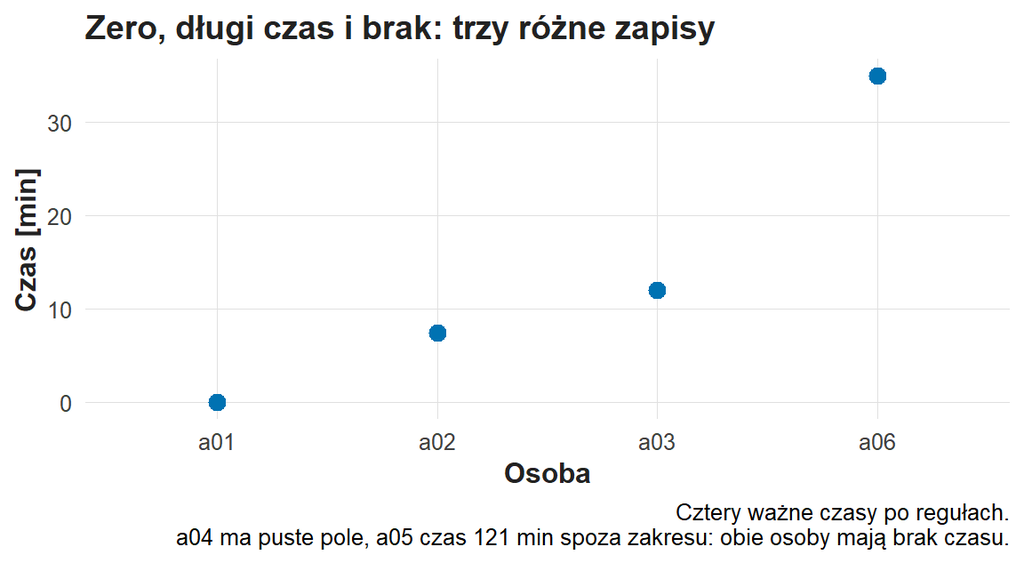

Zero, długi czas i brak: trzy różne zapisy. Oś pozioma: osoby a01, a02, a03 i a06; oś pionowa: czas w minutach. Punkty leżą przy 0; 7,5; 12 i 35 minutach. Osoby a04 (puste pole) i a05 (121 minut poza zakresem) mają brak czasu i nie mają punktu.

Blok wyświetla tabelę „Z prawidłowym długim czasem i bez niego” z N, średnią i medianą dla obu wariantów oraz wykres „Zero, długi czas i brak: trzy różne zapisy”.

*Wskazówki:*

- Średnia zależy od każdej wartości, więc jedna długa próba przesuwa ją silnie; mediana zależy od kolejności wartości.
- Protokół archiwum potwierdza czas 35 minut, a wykluczenie pomiaru wymaga dowodu błędu.
- Oba warianty opisują różne zbiory osób: wszystkie ważne czasy albo osoby bez najdłuższej próby.
- Informacja spoza wykresu to np. zapis przerw, pomocy bibliotekarza albo problemu technicznego w protokole.
- Wzorzec APA: „Cztery ważne czasy dały *M* = [..] min (*Mdn* = [..] min). Po wyłączeniu potwierdzonego pomiaru 35 min średnia wyniosłaby *M* = [..] min (*n* = [..]); pomiar pozostaje w analizie, ponieważ [..]”.

*W akapicie wymagane:* (i) obie średnie i mediany z N; (ii) źródło zmiany średniej; (iii) ocena propozycji z odwołaniem do protokołu; (iv) informacja spoza wykresu potrzebna do oceny czasu 35 minut.

**Twój akapit S04.** Znacznik w nawiasie kwadratowym zastąp własnym tekstem.

## CHALLENGE 5: Notatka o danych gotowych do analizy

Badacz przekazuje przygotowany zbiór osobie opisującej wyniki. Dokumentację tworzy notatka z regułami i mianownikami; nazwa pliku „czyste” pozostaje etykietą.

**Zadanie:** napisz notatkę metodyczną o przygotowaniu danych archiwum w stylu APA.

```r
notatka <- podsumowanie_przygotowania(archiwum_czyste, archiwum_etapy)
print(notatka)
```

**Etapy przygotowania**

| Etap | Rekordy | Czas | Ocena | Powodzenie |
| --- | --- | --- | --- | --- |
| surowe | 7 | 6 | 7 | 6 |
| bez_duplikatu | 6 | 5 | 6 | 5 |
| po_regulach | 6 | 4 | 5 | 5 |

**Dane do krótkiej notatki**

| miara | wartosc |
| --- | --- |
| Osoby po przygotowaniu | 6,000 |
| Ważne czasy | 4,000 |
| Średnia czasu [min] | 13,625 |
| Mediana czasu [min] | 9,750 |
| Ważne oceny | 5,000 |
| Ważne wyniki zadania | 5,000 |
| Powodzenia | 3,000 |
| Powodzenia [% ważnych wyników] | 60,000 |
| Pary czasu i oceny | 3,000 |

Blok wyświetla tabelę „Etapy przygotowania” i tabelę „Dane do krótkiej notatki” z dziewięcioma miarami: osoby, ważne czasy, średnia i mediana czasu, ważne oceny, ważne wyniki, powodzenia, odsetek powodzeń i pary czasu i oceny.

*Wskazówki:*

- Kolejność notatki: N surowe, usunięta kopia, reguły braków, ważne N każdej zmiennej, jedno ograniczenie.
- Liczbę komórek zmienionych regułami podaje różnica między etapami „bez_duplikatu” i „po_regulach” w tabeli „Etapy przygotowania”.
- Ograniczenie wynika z małej syntetycznej próby: przy pięciu znanych wynikach zmiana wyniku jednej osoby przesuwa odsetek powodzeń o 20 punktów procentowych.
- Surowy plik i skrypt pozwalają odtworzyć wynik i sprawdzić każdą liczbę notatki.
- Wzorzec APA: „Eksport zawierał [..] rekordów; po usunięciu [..] identycznej kopii pozostało [..] osób. [..] kod 99 i [..] czas spoza zakresu 0–120 min oznaczono jako braki danych. Dostępnych było [..] ważnych czasów (*M* = [..] min, *Mdn* = [..] min) i [..] wyników zadania, w tym [..] sukcesy ([..]%)”.

*W akapicie wymagane:* (i) N surowe i końcowe z usuniętą kopią; (ii) dwie reguły braków z liczbą komórek; (iii) N ważnego czasu i wyników z miarami; (iv) jedno ograniczenie; (v) powód zachowania surowego pliku i skryptu.

**Twój akapit S05.** Znacznik w nawiasie kwadratowym zastąp własnym tekstem.

# Zapis i oddanie

Porównaj pięć własnych odpowiedzi z wydrukami. Sprawdź, czy odpowiedzi odróżniają liczbę zmienionych komórek od liczby osób i brak od zarejestrowanego zera. Zapisz plik `zadanie.Rmd` w edytorze (Ctrl+S); funkcja oddania tworzy PDF z zapisanego pliku.

W konsoli wykonaj jedno polecenie. Funkcja oddania tworzy aktualny PDF, sprawdza kompletność, otwiera PDF do obejrzenia i po potwierdzeniu literą `t` wysyła go do folderu zadania prowadzącego na serwerze UJ (nc.uj.edu.pl). Nazwa pliku zawiera Twoje ID oraz nazwisko i imię.

```r
oddaj_zadanie("Z02")
```

Oddanie potwierdza komunikat z nazwą wysłanego pliku, folderem i czasem; plik `oddania.csv` w folderze `moje-badania` zapisuje także sumę SHA-256 wysłanego PDF. Po komunikacie błędu popraw wskazany problem, zapisz plik i ponownie wywołaj `oddaj_zadanie("Z02")`; nowa wersja trafia do folderu obok poprzedniej. Ocenę prowadzący przekazuje osobno.

Po potwierdzonym oddaniu możesz zamknąć projekt: Posit Cloud zachowuje folder `moje-badania` do kolejnych zajęć. Na komputerze współdzielonym wyloguj się z Posit Cloud w przeglądarce. Przy braku sieci PDF pozostaje w folderze zadania; wyślij go tym samym poleceniem po odzyskaniu połączenia, a gdy problem trwa, poproś prowadzącego o ustalenie sposobu dostarczenia pracy.

## Co jest oceniane

| Kryterium | Dowód w Twojej pracy | Odpowiedzi | Punkty |
| --- | --- | --- | --- |
| Z02.1 Odczyt importu i struktury surowego eksportu | Liczba wierszy i kolumn, separator pól, znak dziesiętny, typ czasu; rekord eksportu odróżniony od osoby | S01 | 2 |
| Z02.2 Uzasadnienie reguł duplikatów, kodów i długiego czasu | Identyczne powtórzenie a03 i konflikt ID; obsługa 0, 99, 121 i pustego pola; wynik z czasem 35 minut i bez niego | S02, S03, S04 | 4 |
| Z02.3 Bilans osób i dostępnych pomiarów | N surowe, N po usunięciu powtórzeń, ważne N czasu i wyniku, kompletne pary; wiersz odróżniony od komórki i brak od niepowodzenia | S02, S03, S05 | 2 |
| Z02.4 Zgodność opisu z dziennikiem i odtworzenie analizy | Informacja spoza wykresu o czasie 35 minut; reguły, wynik i ograniczenie; powód zachowania surowego źródła | S04, S05 | 2 |

Rubryka ocenia rozumienie reguł i dowodów. Skrypt wykonuje zadanie poprawnie także wtedy, gdy opis jest błędny, np. „usunięto pięć osób” przy zmianie pięciu komórek, dlatego oceniany jest opis. Poziomy wykonania opisuje rubryka Z02: na stronie kursu w dokumencie `rubryki/Z02.html`, a w konsoli R po poleceniu `rubryka("Z02")`.

# Rozwinięcia do powtórki — poza rdzeniem spotkania

Rozwinięcia stosują decyzje z LEARN do pełnego zbioru S02, arkusza i logu zdarzeń. Rozwinięcia służą powtórce i pozostają poza oceną.

## Dziennik pełnego zbioru S02

Reguły S02 są te same co w demonstracji, a liczebności pochodzą z większej tabeli. Tabela „Reguły w pełnym zbiorze S02” podaje pięć wierszy: 150 rekordów przed czyszczeniem, 2 usunięte identyczne duplikaty, 4 kody 99 zamienione na `NA`, 2 czasy spoza 0–120 minut zamienione na `NA` i 148 rekordów po czyszczeniu. Nazwij jednostkę każdej liczby: rekordy albo komórki.

```r
dziennik <- dziennik_s02()
print(dziennik)
```

**Reguły w pełnym zbiorze S02**

| Reguła lub stan | Liczba |
| --- | --- |
| N przed czyszczeniem | 150 |
| Usunięte identyczne duplikaty | 2 |
| Kod 99 zamieniony na NA | 4 |
| Czas poza 0–120 minut zamieniony na NA | 2 |
| N po czyszczeniu | 148 |

Dziennik opisuje działania na rekordach i komórkach. Identyczny duplikat powstaje zwykle w eksporcie, kod 99 zapisuje odmowę albo pominięcie odpowiedzi, a niedopuszczalny czas — np. błąd urządzenia. Język raportu nazywa każdą z trzech sytuacji osobno.

Wykres „Od surowego eksportu do ważnych czasów S02” przedstawia cztery liczby: 150 rekordów surowego eksportu, 148 rekordów po usunięciu duplikatów, 144 rekordy z zapisanym czasem i 142 czasy w zakresie 0–120 minut. Liczba rekordów zmienia się wyłącznie na pierwszym kroku; dwa kolejne kroki dotyczą komórek czasu.

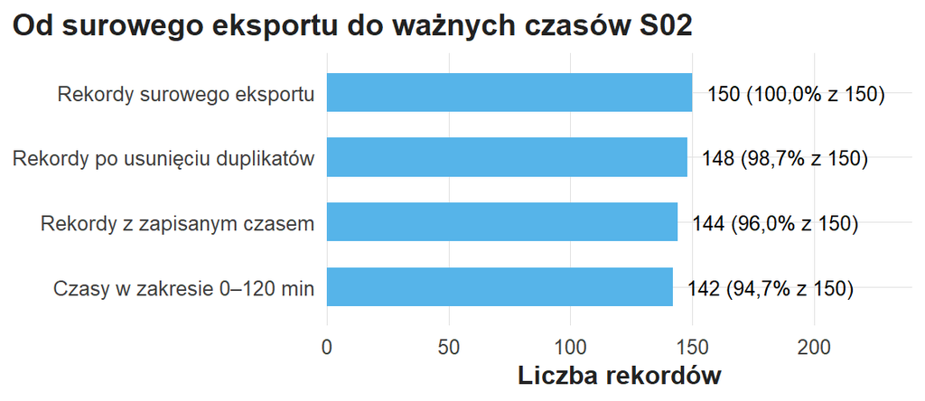

Od surowego eksportu do ważnych czasów S02. Cztery poziome słupki od góry: 150 rekordów surowego eksportu, 148 rekordów po usunięciu duplikatów (98,7% z 150), 144 rekordy z zapisanym czasem (96,0%) i 142 czasy w zakresie 0–120 minut (94,7%).

```r
przeplyw <- pokaz_wykres(wykres_przeplywu)
print(przeplyw)
```

Liczba wierszy po przygotowaniu równa się różnicy surowego N i liczby duplikatów: $150-2=148$. Braki liczy się dla każdej zmiennej osobno, bo jedna osoba może mieć kilka braków. Tabela „Niepuste wartości przed regułami i ważne po regułach” podaje: czas 146 i 142, pozycja 2 — 150 i 144, powodzenie 150 i 148.

```r
liczebnosci_s02 <- bilans_s02()
print(liczebnosci_s02)
```

**Rekordy S02**

| Rekordy surowe | Rekordy po przygotowaniu | Braki czasu |
| --- | --- | --- |
| 150 | 148 | 6 |

**Niepuste wartości przed regułami i ważne po regułach**

| Zmienna | Niepuste przed regułami | Ważne po regułach |
| --- | --- | --- |
| czas_wyszukiwania | 146 | 142 |
| pozycja_2 | 150 | 144 |
| powodzenie | 150 | 148 |

Kolumna „Niepuste przed regułami” obejmuje kody 99, niedopuszczalne czasy i wartości z duplikatów. Dla pozycji 2 różnica $150-144=6$ składa się z 2 wartości w duplikatach i 4 kodów 99. Dla czasu różnica $146-142=4$ składa się z 2 wartości w duplikatach i 2 czasów spoza zakresu.

## Histogram czasu po przygotowaniu

Histogram dzieli oś wartości na przedziały równej szerokości i nad każdym przedziałem rysuje słupek o wysokości równej liczbie osób z wartością w przedziale. Wykres „Czas S02 po zastosowaniu reguł” ma przedziały po 2,5 minuty, zamknięte z prawej strony: przedział $(5;\,7{,}5]$ obejmuje czasy większe od 5 i mniejsze lub równe 7,5 minuty. Suma wysokości wszystkich słupków równa się liczbie ważnych czasów, $N=142$.

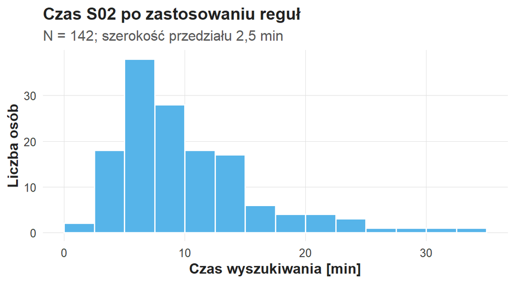

Czas S02 po zastosowaniu reguł: histogram 142 ważnych czasów z przedziałami po 2,5 minuty. Oś pozioma: czas wyszukiwania w minutach; oś pionowa: liczba osób. Najwyższy słupek, 38 osób, stoi nad przedziałem od 5 do 7,5 minuty; słupki obniżają się w prawo, a pojedyncze osoby mają czasy do 33,8 minuty.

```r
rozklad <- pokaz_wykres(wykres_glowny)
print(rozklad)
```

Histogram przedstawia rozkład z długim prawym ogonem: 20 osób ma czas do 5 minut, 66 osób od 5 do 10 minut, 35 osób od 10 do 15 minut, 10 osób od 15 do 20 minut, a 11 osób powyżej 20 minut. Mediana wynosi 8,25 minuty. Mechanizm powstawania sześciu braków czasu wymaga informacji spoza rozkładu, np. protokołu zadania.

Długi czas jest informacją o trudności zadania. Protokół przerywający wszystkie próby po dziesięciu minutach ograniczyłby opis do prób zakończonych przed limitem; ograniczenie wynikające z limitu zapisuje się obok wyniku.

## CSV i arkusz przekazują tę samą informację

Arkusz ułatwia oglądanie danych i przechowuje formatowanie, formuły, scalone komórki i kilka tabel obok siebie. Analiza wymaga jednoznacznej prostokątnej tabeli: jeden wiersz nagłówka z nazwami kolumn, a pod nim wartości tej samej jednostki obserwacji.

Pakiet kursu zawiera surowy CSV zbioru S02 oraz mały arkusz do nauki importu. Arkusz jest wycinkiem danych, a porównanie dotyczy znaczenia i zapisu odpowiadających sobie kolumn.

Odczyt korzysta z plików zapisanych w zainstalowanym pakiecie. Tabela „Lokalne pliki dwóch formatów” podaje wymiary: CSV ma 150 wierszy i 15 kolumn, arkusz ćwiczeniowy — 12 wierszy i te same 15 kolumn.

```r
pliki <- porownanie_formatow()
print(pliki)
```

**Lokalne pliki dwóch formatów**

| zrodlo | wiersze | kolumny |
| --- | --- | --- |
| CSV | 150 | 15 |
| Arkusz ćwiczeniowy | 12 | 15 |

Komunikat o pakiecie `readxl` dotyczy środowiska i zgłasza brakujące narzędzie; `readxl` instaluje się razem z pakietem kursu, więc komunikat oznacza niepełną instalację do zgłoszenia prowadzącemu. Zadanie Z02 i pozostałe przykłady korzystają z CSV.

Tabela „Wybrane kolumny arkusza” zawiera identyfikator, grupę, czas i powodzenie sześciu pierwszych wierszy arkusza. Odczytaj identyfikator, etykietę grupy i jednostkę czasu. Format liczby w arkuszu dotyczy wyświetlania; wartość w analizie pozostaje ta sama.

```r
arkusz <- podglad_arkusza()
print(arkusz)
```

**Wybrane kolumny arkusza**

| ID | Grupa | Czas [min] | Powodzenie |
| --- | --- | --- | --- |
| o001 | nowi | 12,1 | 0 |
| o002 | nowi | 10,4 | 1 |
| o003 | doświadczeni | 5,8 | 1 |
| o004 | doświadczeni | 16,1 | 1 |
| o005 | doświadczeni | 28,0 | 1 |
| o006 | doświadczeni | 6,3 | 0 |

Jednostkę zapisuje się w słowniku lub nagłówku opisowym, a wartość jako liczbę: zapis „8 min” w komórce zmienia kolumnę liczbową w tekstową. Niepowodzenie i wykluczenie zapisuje się w osobnej kolumnie, bo eksport do CSV usuwa kolory komórek.

**Most do pracy z arkuszem.** Otwórz plik ćwiczeniowy tylko do odczytu, wskaż jeden rekord i porównaj go z tabelą „Wybrane kolumny arkusza”. Sprawdź, czy puste pole pozostało puste oraz czy „doświadczeni” zachowuje polskie znaki. Arkusz służy kontroli zgodności odczytu, a wszystkie zmiany danych wykonuje skrypt.

## Od logu zdarzeń do wyniku osoby

Log katalogu ma zwykle po jednym wierszu dla każdego kliknięcia, a ankieta — po jednym wierszu dla osoby. Połączenie obu tabel wymaga ustalenia poziomu danych, bo w przeciwnym razie odpowiedzi ankietowe powielają się tyle razy, ile osoba ma zdarzeń.

Tabela „Pięć zdarzeń, dwie osoby” jest osobnym przykładem dwóch sesji. Pięć wierszy logu opisuje dwie osoby: u01 ma trzy zdarzenia (start w minucie 0, filtr w minucie 1, koniec w minucie 6,5), a u02 dwa zdarzenia (start w minucie 0, koniec w minucie 8).

```r
zdarzenia <- pokaz_tabele(log_demo, "Pięć zdarzeń, dwie osoby")
print(zdarzenia)
```

**Pięć zdarzeń, dwie osoby**

| id | minuta | zdarzenie |
| --- | --- | --- |
| u01 | 0,0 | start |
| u01 | 1,0 | filtr |
| u01 | 6,5 | koniec |
| u02 | 0,0 | start |
| u02 | 8,0 | koniec |

Wykres „Dwie sesje w logu zdarzeń” umieszcza każdą osobę w osobnym wierszu. Odcinek biegnie od pierwszego do ostatniego zdarzenia, punkty z podpisami oznaczają zdarzenia, a liczba przy końcu odcinka podaje długość sesji.

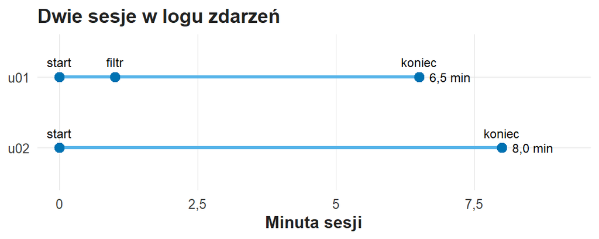

Dwie sesje w logu zdarzeń. Oś pozioma: minuta sesji. Wiersz u01: zdarzenia start (0), filtr (1) i koniec (6,5), odcinek o długości 6,5 minuty. Wiersz u02: zdarzenia start (0) i koniec (8), odcinek o długości 8 minut.

```r
sesje_wykres <- pokaz_wykres(wykres_logu)
print(sesje_wykres)
```

Czas sesji $y_i$ osoby $i$ jest różnicą znaczników czasu ostatniego i pierwszego zdarzenia:

$$y_i=c_{i,\mathrm{koniec}}-c_{i,\mathrm{start}}: \qquad y_{\mathrm{u01}}=6{,}5-0=6{,}5, \qquad y_{\mathrm{u02}}=8-0=8 \text{ minut},$$

gdzie $c$ oznacza znacznik czasu zdarzenia w minutach od początku sesji. Indeks $i$ oznacza osobę lub sesję zgodnie z definicją. Reguła ma sens, bo log zapisuje start i koniec jawnie; w rzeczywistych logach ostatnie kliknięcie bywa wcześniejsze od zakończenia pracy, a długa przerwa oznacza nieaktywność. Definicja sesji poprzedza obliczenie. Gdy osoba ma kilka sesji, grupowanie wyłącznie według ID osoby łączy odrębne wizyty w jeden bardzo długi czas.

Tabela „Czas od początku do końca sesji” podaje jedną wartość na osobę: u01 6,5 i u02 8 minut. Agregacja zmienia poziom danych z kliknięcia na osobę.

```r
sesje <- pokaz_tabele(agregat_demo, "Czas od początku do końca sesji")
print(sesje)
```

**Czas od początku do końca sesji**

| id | czas_min |
| --- | --- |
| u01 | 6,5 |
| u02 | 8,0 |

Połączenie ankiety z logiem wymaga kontroli klucza: jedno ID ankiety odpowiada jednemu uzgodnionemu wynikowi zadania. Po połączeniu kontroluje się N i liczbę dopasowanych rekordów. Wzrost tabeli ze 150 do 620 wierszy po dopisaniu kliknięć zmienia jednostkę wiersza, a liczba osób pozostaje 150.

## Szeroko, długo i w innej jednostce

Sześć pozycji ankiety zapisanych w sześciu kolumnach jednej osoby tworzy układ szeroki. W układzie długim każda osoba ma sześć wierszy z nazwą pozycji i odpowiedzią. Oba układy przechowują tę samą informację i wymagają innego liczenia wierszy.

Przekształcenie 150 osób z sześcioma pozycjami do układu długiego daje 900 wierszy, a liczba osób pozostaje 150. Statystyka pojedynczej pozycji zachowuje mianownik osób z odpowiedzią na tę pozycję.

Transpozycja, czyli zamiana wierszy z kolumnami, zmienia układ prezentacji, np. pojedynczego rekordu na ćwiczeniu C01. Struktura danych i projekt pozostają przy transpozycji takie same.

Przeliczenie jednostki zmienia zapis wartości: 8 minut to 480 sekund. Dziennik podaje wzór przeliczenia i nową jednostkę. Skalowanie do przedziału 0–1 i standaryzacja zmieniają sposób wyrażenia wartości; wymagają uzasadnienia w pytaniu badawczym.

| Operacja | Co się zmienia? | Co należy zachować? |
| --- | --- | --- |
| Usunięcie identycznego duplikatu | Liczba rekordów | Jedna kopia informacji o osobie |
| Rekodacja 99 na NA | Znaczenie wskazanej komórki | Jawna informacja o braku |
| Minuty na sekundy | Jednostka i wartość liczbowa | Ten sam czas zdarzenia |
| Szeroko na długo | Układ tabeli i liczba wierszy | Identyfikator osoby oraz pozycji |
| Agregacja logu | Poziom obserwacji | Reguła wyznaczenia wyniku sesji |
| Standaryzacja | Skala wyrażenia wartości | Parametry odniesienia i interpretacja |

### Sortowanie, rangi i skalowanie na czterech czasach

Przykład dotyczy czterech osób a, b, c i d spoza danych zadania Z02, z czasami 2, 4, 4 i 8 minut. Pięć reprezentacji opisują wzory:

$$x^{(\mathrm{s})}_i=60\,x_i, \qquad
x^{*}_i=\frac{x_i-\min x}{\max x-\min x}, \qquad
z_i=\frac{x_i-\bar{x}}{s}, \qquad
s=\sqrt{\frac{\sum_{i=1}^{n}(x_i-\bar{x})^2}{n-1}}, \qquad
\log_2 x_i .$$

| Symbol | Nazwa | Rachunek dla czterech czasów |
| --- | --- | --- |
| $x_i$ | czas osoby $i$ w minutach | 2, 4, 4, 8 |
| $x^{(\mathrm{s})}_i$ | ten sam czas w sekundach | 120, 240, 240, 480 |
| $\min x$, $\max x$ | najmniejszy i największy czas | 2 i 8 minut |
| $x^{*}_i$ | wartość po skalowaniu min–max | $(4-2)/(8-2)=1/3\approx 0{,}333$ dla 4 minut |
| $\bar{x}$ | średnia | $18/4=4{,}5$ minuty |
| $s$ | odchylenie standardowe (SD): typowa odległość od średniej | $\sqrt{19/3}\approx 2{,}52$ minuty |
| $z_i$ | wynik standaryzowany | $(8-4{,}5)/2{,}52\approx 1{,}39$ dla 8 minut |
| $\log_2 x_i$ | logarytm o podstawie 2 | 1, 2, 2, 3 |

Tabela „Cztery osoby: ta sama informacja, różne przekształcenia” zestawia w jednym wierszu tę samą obserwację we wszystkich reprezentacjach.

```r
przeliczenia <- przyklad_transformacji()
print(przeliczenia)
```

**Cztery osoby: ta sama informacja, różne przekształcenia**

| ID | minuty | sekundy | ranga | min_max | z | log2 |
| --- | --- | --- | --- | --- | --- | --- |
| a | 2 | 120 | 1,0 | 0,000 | -0,993 | 1 |
| b | 4 | 240 | 2,5 | 0,333 | -0,199 | 2 |
| c | 4 | 240 | 2,5 | 0,333 | -0,199 | 2 |
| d | 8 | 480 | 4,0 | 1,000 | 1,391 | 3 |

Wykres „Cztery czasy w pięciu skalach” ma pięć poziomych osi, po jednej na reprezentację: wartość w minutach, rangę, min–max, standaryzację z i log2. Punkty mają podpisy osób.

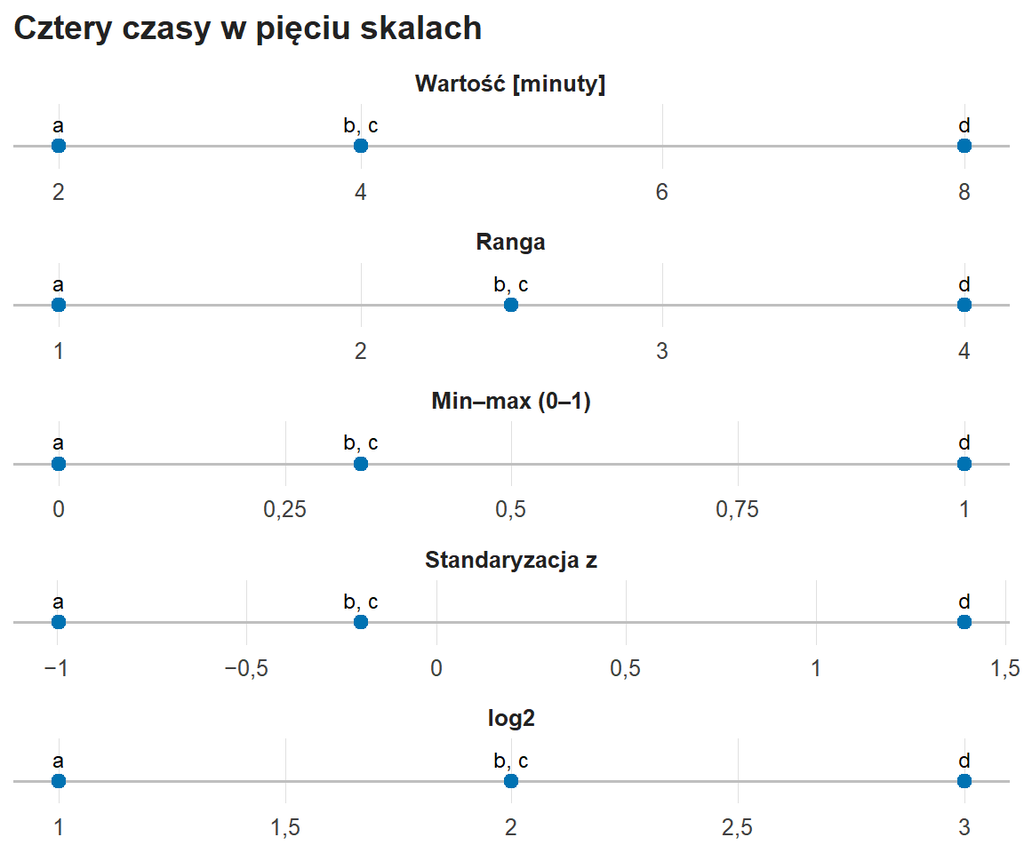

Cztery czasy w pięciu skalach. Pięć poziomych osi od góry: minuty (2, 4, 4, 8), rangi (1; 2,5; 2,5; 4), min–max (0; 0,333; 0,333; 1), standaryzacja z (−0,99; −0,20; −0,20; 1,39) i log2 (1, 2, 2, 3). Osoby b i c mają ten sam punkt na każdej osi, a kolejność a, b i c, d jest wszędzie ta sama.

```r
skale <- pokaz_wykres(wykres_transformacji)
print(skale)
```

Kolejność czterech osób jest na każdej osi ta sama, a odległości się zmieniają. Sortowanie porządkuje całe rekordy według czasu i zachowuje identyfikator oraz pozostałe dane osoby; posortowanie samej kolumny w arkuszu przypisuje czasy innym osobom. Ranga nadaje pozycję w porządku: czasy 4 i 4 minuty zajmują miejsca drugie i trzecie, więc obie mają średnią rangę 2,5. Ranga zachowuje kolejność; odległość w minutach pozostaje w kolumnie czasu.

Skalowanie min–max, nazywane też normalizacją do zakresu 0–1, przypisuje 0 najkrótszemu i 1 najdłuższemu czasowi w zestawie. Dopisanie czasu 20 minut zmienia wartości min–max wszystkich pozostałych osób, więc porównanie grup wymaga wspólnych parametrów $\min x$ i $\max x$.

Standaryzacja wyraża odległość od średniej w jednostkach SD: $z=1{,}39$ oznacza czas o 1,39 SD dłuższy od średniej. Min–max i standaryzacja zachowują kształt rozkładu. Przy identycznych wartościach mianownik obu reguł wynosi zero, więc obie reguły wymagają co najmniej dwóch różnych wartości.

Logarytm o podstawie 2 odpowiada na pytanie: do jakiej potęgi trzeba podnieść 2, aby otrzymać daną liczbę? $\log_2 8=3$, a $\log_2 4=2$. Różnica jednego na skali log2 oznacza podwojenie czasu: odstęp 2→4 minuty równa się odstępowi 4→8 minut. Równe odstępy logarytmów odpowiadają równym stosunkom czasów. Logarytm istnieje dla liczb dodatnich, a wybór transformacji wynika z pytania i trafia do reguł analizy.

## Brak danych a przebieg badania

Brak techniczny, odmowa odpowiedzi i niewykonane zadanie mają różne źródła. W pliku wszystkie trzy mogą wystąpić jako `NA`, a protokół rozróżnia je osobnymi kodami, gdy zebrano taką informację. Przyczynę braku podaje protokół.

Gdy braki czasu występują częściej przy problemach z interfejsem, analiza samych zmierzonych czasów przedstawia usługę korzystniej od rzeczywistości. Gdy osoby niezadowolone rzadziej kończą ankietę, średnia deklarowanej użyteczności dotyczy bardziej zadowolonej części użytkowników. Mechanizm braków ocenia się na podstawie procesu zbierania danych.

Raport podaje liczbę braków każdej analizowanej zmiennej i ich rozkład między grupami. Tabela braków w grupach wskazuje wzorzec dostępności danych; zależność braków od nieobserwowanych wartości pozostaje założeniem.

Podstawienie średniej za brak zmniejsza zróżnicowanie i zniekształca związki między zmiennymi. Brak pozostaje brakiem do czasu przyjęcia jawnej, uzasadnionej metody analizy.

## Dodatkowe przykłady z rozwiązaniem

### Próba A: pozorne zwiększenie próby

Ankietę wypełniło 120 osób. Po połączeniu z logiem tabela ma 800 wierszy. Autor raportu pisze „N = 800 użytkowników”. Co sprawdzić przed poprawieniem liczby?

Najpierw sprawdzamy poziom rekordu po połączeniu: osoba, sesja albo zdarzenie. Gdy jeden uczestnik ma wiele kliknięć, 800 jest liczbą zdarzeń. Liczbę użytkowników wyznaczają identyfikatory osób i reguła włączenia. Analiza wspólna obejmuje ankiety z dopasowanym logiem, więc jej N wymaga kontroli dopasowania i bywa mniejsze od 120.

### Próba B: braki a granice odsetka

Wynik zadania zarejestrowano dla 80 ze 100 osób. Wśród znanych wyników było 60 powodzeń. Czy sukces odniosło 60% czy 75% uczestników?

Wśród 80 znanych wyników odsetek powodzeń wynosi $60/80=75\%$, a 60% to odsetek zapisanych powodzeń wśród wszystkich stu osób. Pełny odsetek $\pi_{\mathrm{pełne}}$ w stu próbach leży między dwoma skrajnymi wariantami braków:

$$\frac{k}{N}\le\pi_{\mathrm{pełne}}\le\frac{k+m}{N}: \qquad \frac{60}{100}=60\% \;\le\; \pi_{\mathrm{pełne}} \;\le\; \frac{80}{100}=80\%,$$

gdzie $k=60$ to liczba powodzeń, $m=20$ liczba braków, a $N=100$ liczba osób. Dolna granica odpowiada niepowodzeniu wszystkich osób z brakiem, górna — ich powodzeniu. Raport nazywa mianownik i liczbę braków.

### Próba C: odrzucenie najdłuższych wyszukiwań

Autor usuwa wszystkie czasy powyżej mediany i stwierdza, że system działa szybko. Reguła z definicji usuwa dłuższą połowę obserwacji. Średnia po usunięciu połowy obserwacji opisuje szybszą połowę próby.

Protokół wykazujący, że określone znaczniki czasu zapisano w sekundach, uzasadnia korektę jednostki. Korekta opiera się na dowodzie o pomiarze.

### Próba D: niezgodne słowniki

Jeden plik koduje powodzenie jako 1, drugi jako 2. Po połączeniu kolumna zawiera wartości 0, 1 i 2. Kod 2 wymaga odwzorowania na wspólną definicję wyniku.

Odwzorowanie kodów zapisuje się jawnie w skrypcie. Wspólna etykieta wymaga też wspólnego kryterium sukcesu: odnalezienie rekordu i poprawna ocena wiarygodności publikacji to dwa różne kryteria.

## Braki w dwóch grupach

Porównanie nowych i doświadczonych użytkowników wymaga sprawdzenia, czy pomiar czasu pomijano podobnie w obu grupach. Niewielka ogólna liczba braków może skupiać się w grupie kluczowej dla pytania. Odsetek braków zmiennej w grupie $g$ zapisuje wzór

$$b_g=\frac{m_g}{N_g}\cdot 100\%: \qquad b_{\mathrm{doświadczeni}}=\frac{4}{74}\cdot 100\%\approx 5{,}4\%, \qquad b_{\mathrm{nowi}}=\frac{2}{74}\cdot 100\%\approx 2{,}7\%,$$

gdzie $m_g$ to liczba braków czasu w grupie $g$, a $N_g$ liczba osób w grupie. Mianownikiem odsetka braków w grupie jest liczba osób w grupie: 74 doświadczonych i 74 nowych.

Chunk `braki-w-grupach` wyświetla tabelę „Mianownik odsetka braków to liczba osób w danej grupie” i wykres „Braki trzech zmiennych w dwóch grupach S02”. Tabela podaje dla doświadczonych 74 osoby, 70 ważnych czasów i 4 braki (5,4%), a dla nowych 74 osoby, 72 ważne czasy i 2 braki (2,7%).

```r
braki <- braki_w_grupach()
print(braki)
```

**Mianownik odsetka braków to liczba osób w danej grupie**

| Grupa | Osoby | Ważne czasy | Braki | Braki [%] |
| --- | --- | --- | --- | --- |
| doświadczeni | 74 | 70 | 4 | 5,4 |
| nowi | 74 | 72 | 2 | 2,7 |

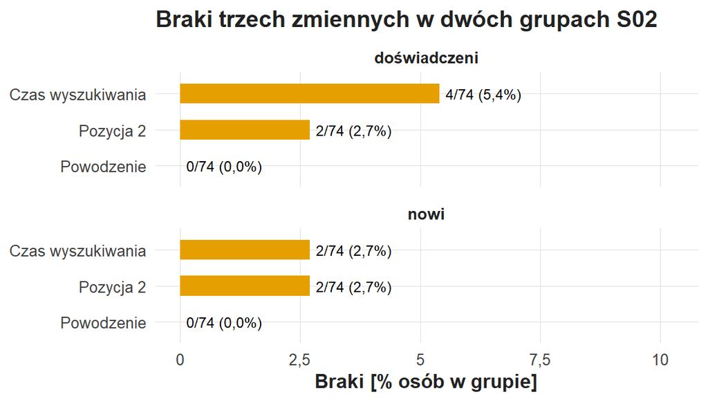

Braki trzech zmiennych w dwóch grupach S02. Dwa panele, doświadczeni i nowi; w każdym poziome słupki odsetka braków dla czasu wyszukiwania, pozycji 2 i powodzenia. Doświadczeni: czas 4/74 (5,4%), pozycja 2 2/74 (2,7%), powodzenie 0/74 (0,0%). Nowi: czas 2/74 (2,7%), pozycja 2 2/74 (2,7%), powodzenie 0/74 (0,0%).

Tabela i wykres opisują dostępność pomiarów; wartości brakujących czasów pozostają nieznane. Podobne odsetki braków są zgodne z sytuacją, w której w jednej grupie zabrakło najkrótszych prób, a w drugiej najdłuższych.

Odrębny przykład: zaproszono po 50 osób z dwóch grup, a czas zapisano dla 30 nowych i 45 doświadczonych. Średnie obliczone z zapisanych czasów dotyczą dwóch podzbiorów o różnej kompletności: 60% i 90%. Interpretacja różnicy średnich jako różnicy doświadczenia wymaga ustalenia przyczyny brakujących pomiarów.

## Dwa rodzaje zdania o jakości danych

Zdanie „dane są poprawne, bo funkcja wykonała się bez błędu” obejmuje więcej, niż potwierdza kontrola. Wykonanie funkcji bez błędu potwierdza warunki techniczne; opis jednostki, rezygnacje uczestników i rozumienie pytań wymagają kontroli merytorycznej.

Lepsza wersja rozdziela sprawdzony fakt i pozostałą niewiedzę: „Po zastosowaniu reguł zbiór zawiera wyłącznie unikalne rekordy, a ważne odpowiedzi pozycji mieszczą się w zakresie 1–5. Związek przyczyn braków czasu z trudnością zadania pozostaje nieznany”. Pierwsze zdanie odsyła do danych, drugie do ograniczenia projektu.

Rozróżnienie przydaje się w analizach instytucjonalnych. Kompletne logi opisują zachowanie w systemie, a potrzeby użytkowników wymagają osobnego pomiaru; poprawnie zakodowana ankieta wymaga jeszcze trafnych pytań. Kontrola danych i kontrola pomiaru uzupełniają się.

Ćwiczenie C03 (Portret próby: czas wyszukiwania, skuteczność i zróżnicowanie) opisuje rozkład czasu i skuteczność zadania średnią, medianą i histogramem obliczonymi dla jawnie określonych danych. Wynik C02 ustala, o czyim zachowaniu i jakim pomiarze mówią dalsze analizy.

Przed C03 odpowiedz bez komputera: od czego zależy N czasu w porównaniu z liczbą osób; jak postępujemy z ujemnym czasem, a jak z długim czasem w zakresie; ile osób opisuje układ długi sześciu pozycji dla 150 osób; które informacje osoby zostają przy brakującej ocenie. Każdą odpowiedź połącz z jednym konkretnym rekordem lub regułą.